# Portfolio Insurance Trading Strategies

Futures trading strategies for price risk management, for commercial hedgers with long or short exposure. All models below aim to achieve a favorable unit price for the energy portfolio, while preventing it from breaching a pre defined cap (floor).

The functions

- `cppi()` - Constant Proportion Portfolio Insurance
- `dppi()` - Dynamic Proportion Portfolio Insurance
- `obpi()` - Option Based Portfolio Insurance
- `shpi()` - Step Hedge Portfolio Insurance
- `slpi()` - Stop Loss Portfolio insurance

implement alternative approaches to achieve this goal. They return S4 objects of type `CPPI`, `DPPI`, `OBPI`, `SHPI` and `SLPI` respectively, with methods `plot()`, `summary()` and `show()`.

We will illustrate with some examples using the synthetic `powcal` data set, which is included in `etrm`. The data set contains daily closing prices for a set of yearly baseload power futures contracts:

```r
library(etrm)
data(powcal)

# the first five contracts
head(powcal[1:6])
```

```
#>         Date CAL-06 CAL-07 CAL-08 CAL-09 CAL-10
#> 1 2003-01-02  24.29     NA     NA     NA     NA
#> 2 2003-01-03  24.91     NA     NA     NA     NA
#> 3 2003-01-07  24.67     NA     NA     NA     NA
#> 4 2003-01-08  24.59     NA     NA     NA     NA
#> 5 2003-01-09  24.39     NA     NA     NA     NA
#> 6 2003-01-10  24.29     NA     NA     NA     NA
```

In our example, we will consider the CAL-06 contract, and start trading 500 days prior to the contract expiry.

```r
day06 <- powcal$Date[!is.na(powcal$`CAL-06`)]
cal06 <- powcal$`CAL-06`[!is.na(powcal$`CAL-06`)]
dat06 <- data.frame(Date = day06, CAL06 = cal06)
dat06 <- tail(dat06, 500)
```

We will use the `obpi()` function to implement option-based portfolio insurance, e.g. we synthesize an option via a delta hedging scheme. For the `OBPI`strategy, the target price is calculated as an expected cap (floor) given by the option premium-adjusted strike price selected for the delta hedging scheme within a standard Black-76 option pricing framework. The default strike price is set at-the-money. The user may express a view regarding future market development by deviating from this level.

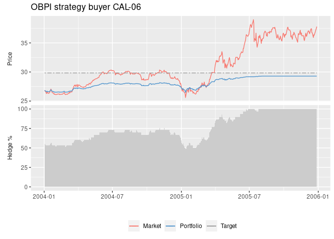

```r
cal06_obpi_b <- obpi(q = 30,               # volume 30 MW (buyer)
                     tdate = dat06$Date,   # vector with trading days until expiry
                     f = dat06$CAL06,      # vector with futures price
                     k = dat06$CAL06[1],   # default option strike price at-the-money
                     vol = 0.2,            # annualized volatility, for the Black-76 delta hedging
                     r = 0,                # default assumed risk free rate of interest
                     tdays = 250,          # assumed trading days per year
                     daysleft = 500,       # number of days to expiry
                     tcost = 0,            # transaction cost
                     int = TRUE            # integer restriction, smallest transacted unit = 1
                   )

plot(cal06_obpi_b, legend = "bottom", title = "OBPI strategy buyer CAL-06")
```

The `summary()` method:

```r
summary(cal06_obpi_b)
```

```
#> $Description
#> [1] "Hedging strategy of type OBPI and length 500"
#>
#> $Volume
#> [1] 30
#>
#> $Target
#> [1] 29.83626
#>
#> $ChurnRate
#> [1] 4.333333
#>
#> $Stats
#>       Market Trade Exposed Position     Hedge   Target Portfolio
#> First  26.82    17      13       17 0.5666667 29.83626  26.82000
#> Max    39.01    17      17       30 1.0000000 29.83626  29.29433
#> Min    25.60    -3       0       13 0.4333333 29.83626  26.46833
#> Last   37.81     0       0       30 1.0000000 29.83626  29.29433
```

The `show()`method provide details regarding daily values for market price, transactions, exposed volume, futures contract position, the target price and the calculated portfolio price. Further details for a specific instance of a trading strategy can be found in the slots, see for example:

```r
slotNames(cal06_obpi_b)
```

```
#>  [1] "StrikePrice"  "AnnVol"       "InterestRate" "TradingDays"  "Name"
#>  [6] "Volume"       "TargetPrice"  "TransCost"    "TradeisInt"   "Results"
```

The strategy CAL-06 OBPI strategy from a sellers point of view:

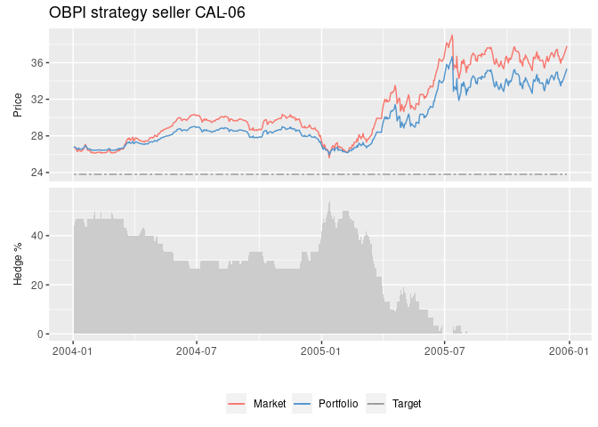

```r
cal06_obpi_s <- obpi(q = - 30,             # volume -30 MW (seller)
                     tdate = dat06$Date,   # vector with trading days until expiry
                     f = dat06$CAL06,      # vector with futures price
                     k = dat06$CAL06[1],   # default option strike price at-the-money
                     vol = 0.2,            # annualized volatility, for the Black-76 delta hedging
                     r = 0,                # default assumed risk free rate of interest
                     tdays = 250,          # assumed trading days per year
                     daysleft = 500,       # number of days to expiry
                     tcost = 0,            # transaction cost
                     int = TRUE            # integer restriction, smallest transacted unit = 1
                   )

plot(cal06_obpi_s, legend = "bottom", title = "OBPI strategy seller CAL-06")
```